# Manifestation of the climate change in Texas from 1950 until today

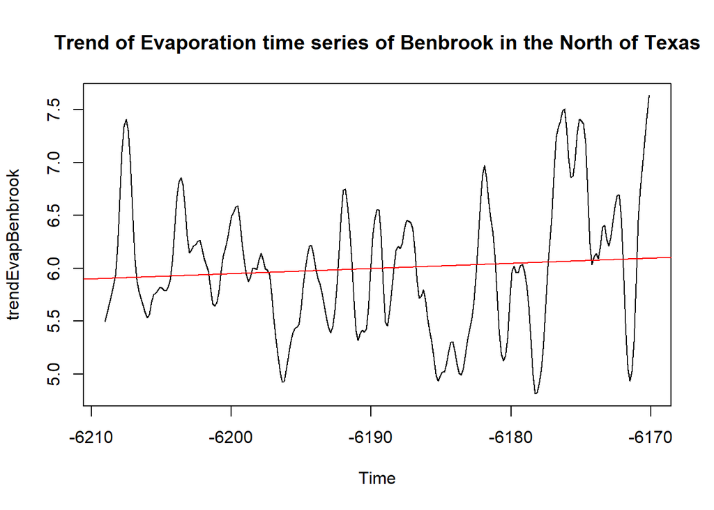

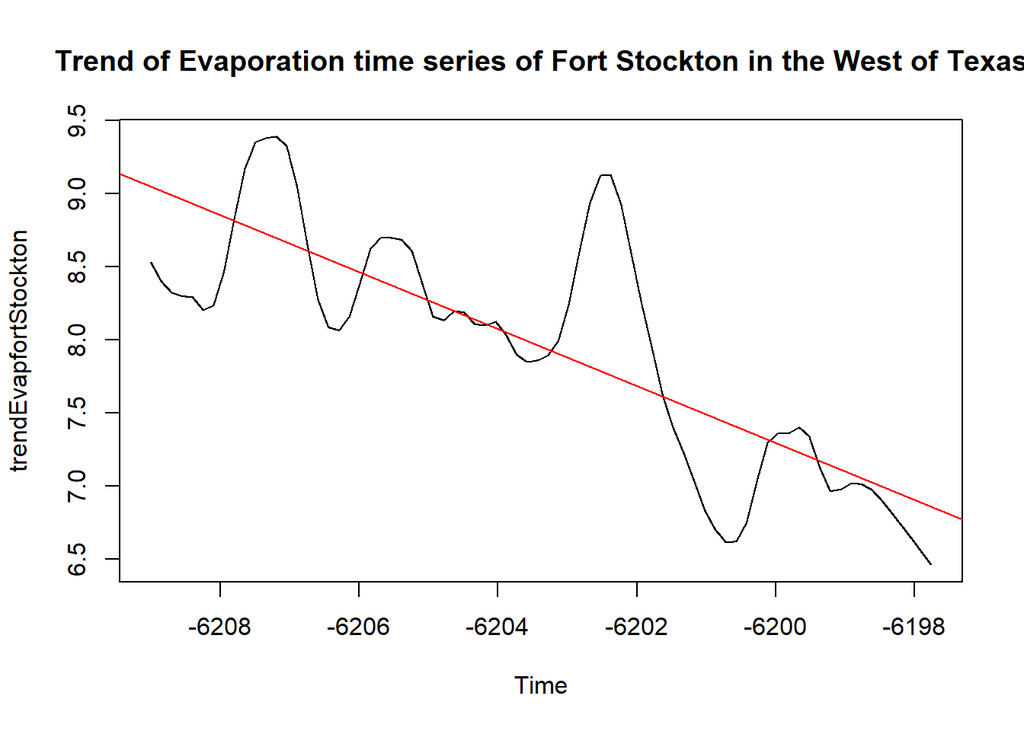

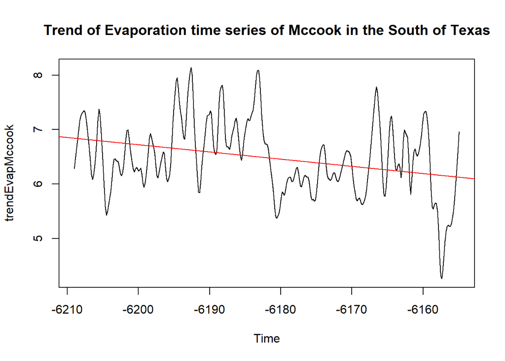

The autocorrelation plot for Angleton shows the seasonal periodicities of the evaporation. In the winter there is only very little evaporation compared to the summer.

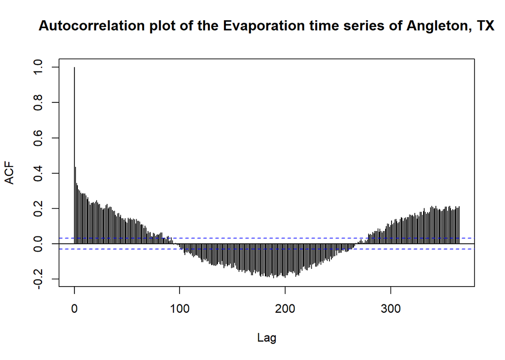

According to the decreasing trend, also most of the forecasts expect a further decrease of evaporation. Interestingly, the forecast for Mccook is strongly rising in the first days although it has a decreasing trend. Overall the forecasts are rather static with only small changes.

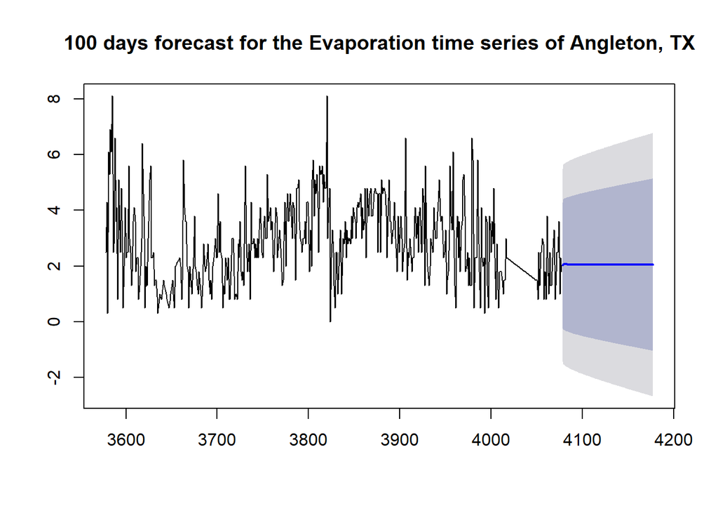

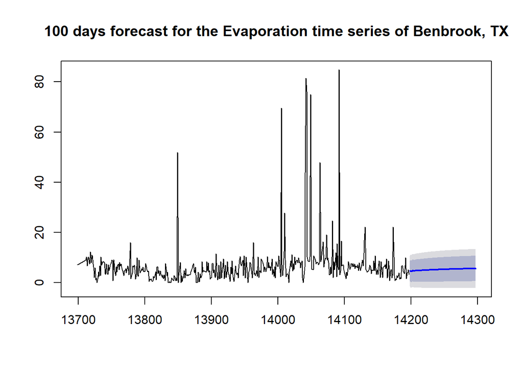

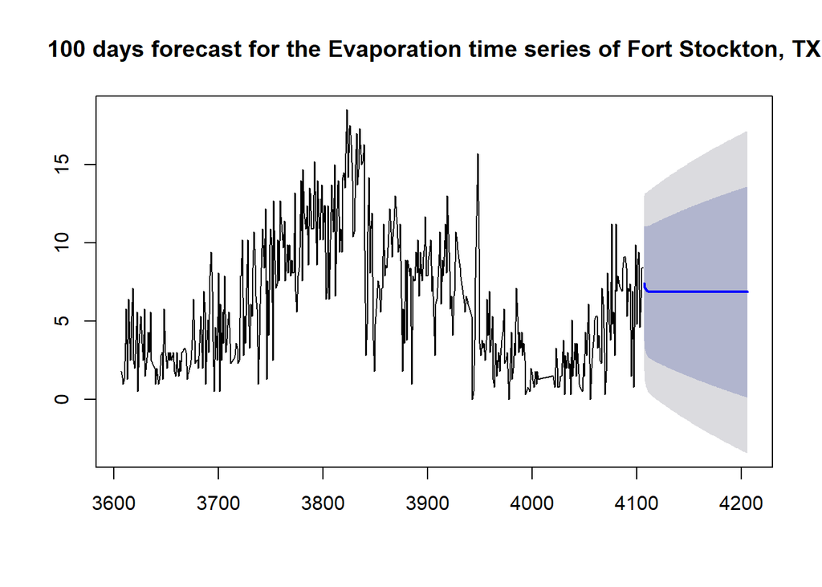

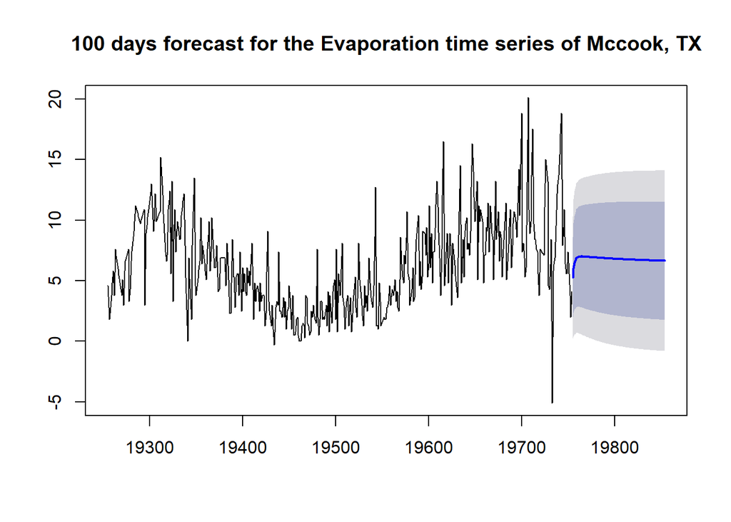

#### Averaged monthly data

The kriging interpolation for January is not showing a clear trend in the one or the other direction. Matching to the kriging results of temperature we see that the evaporation is strongest in the regions where temperature is high. In this case this is at the border to Mexico in the southwest of Texas.

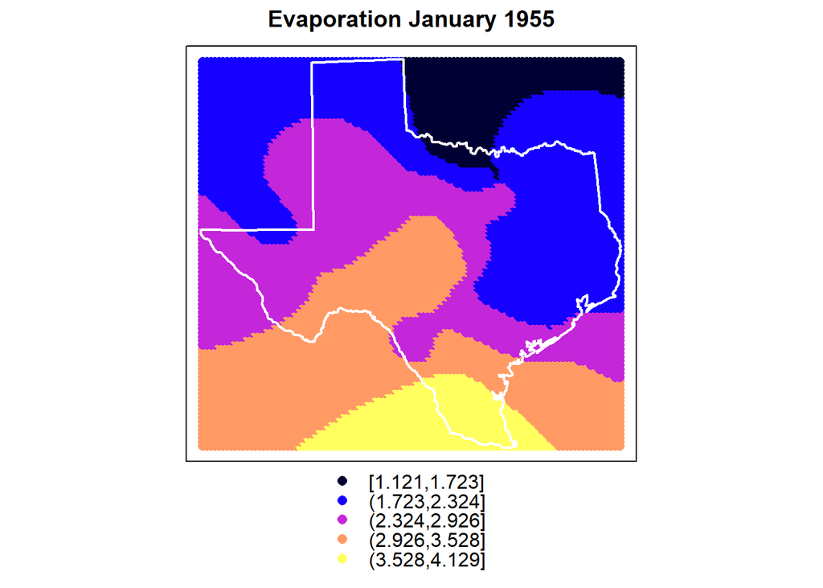

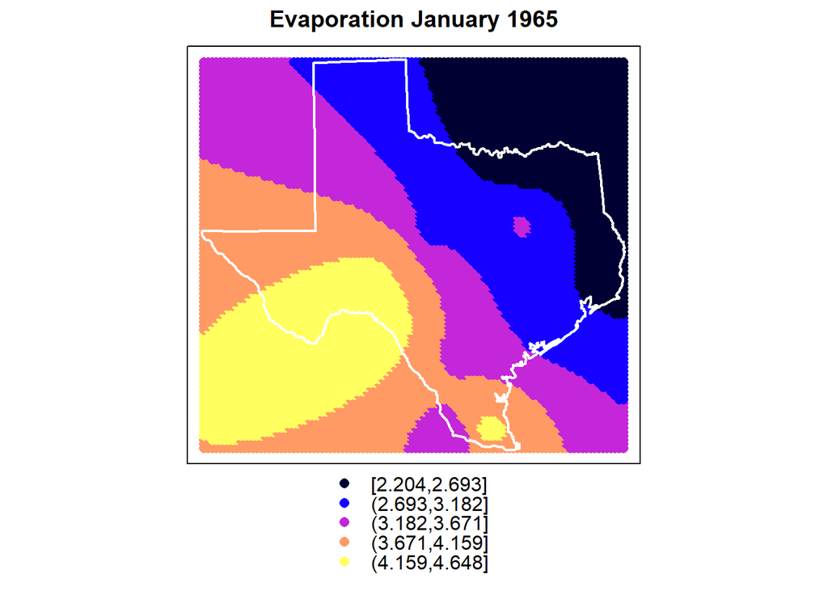

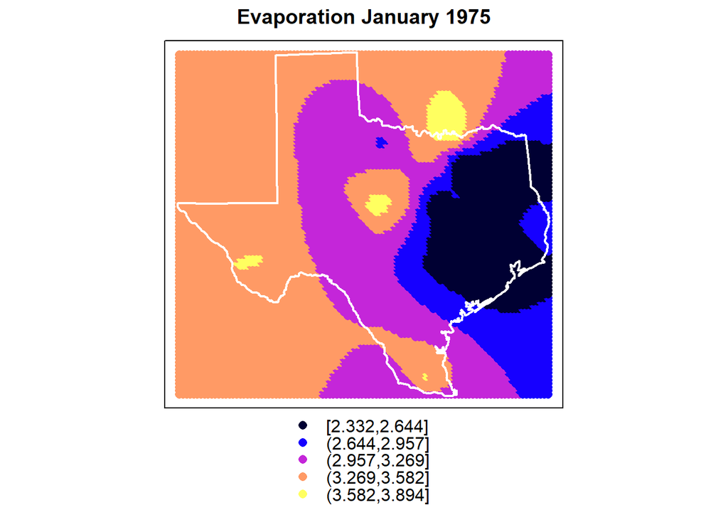

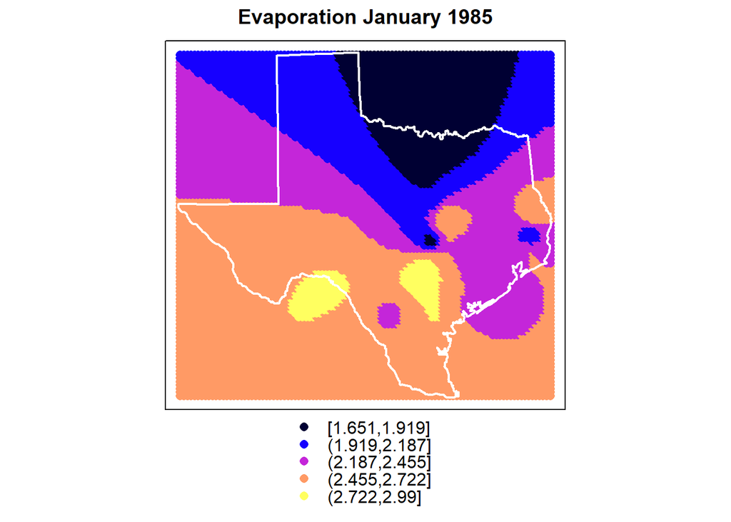

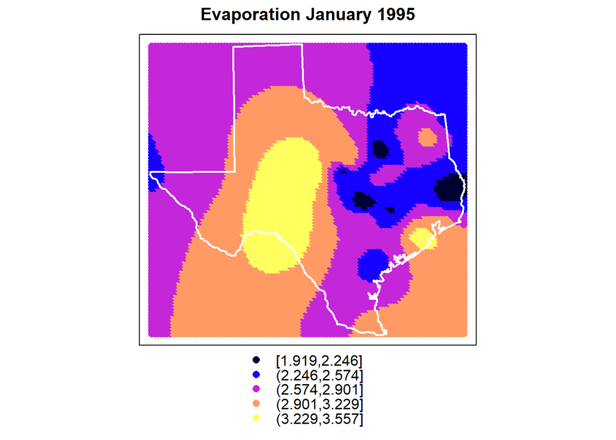

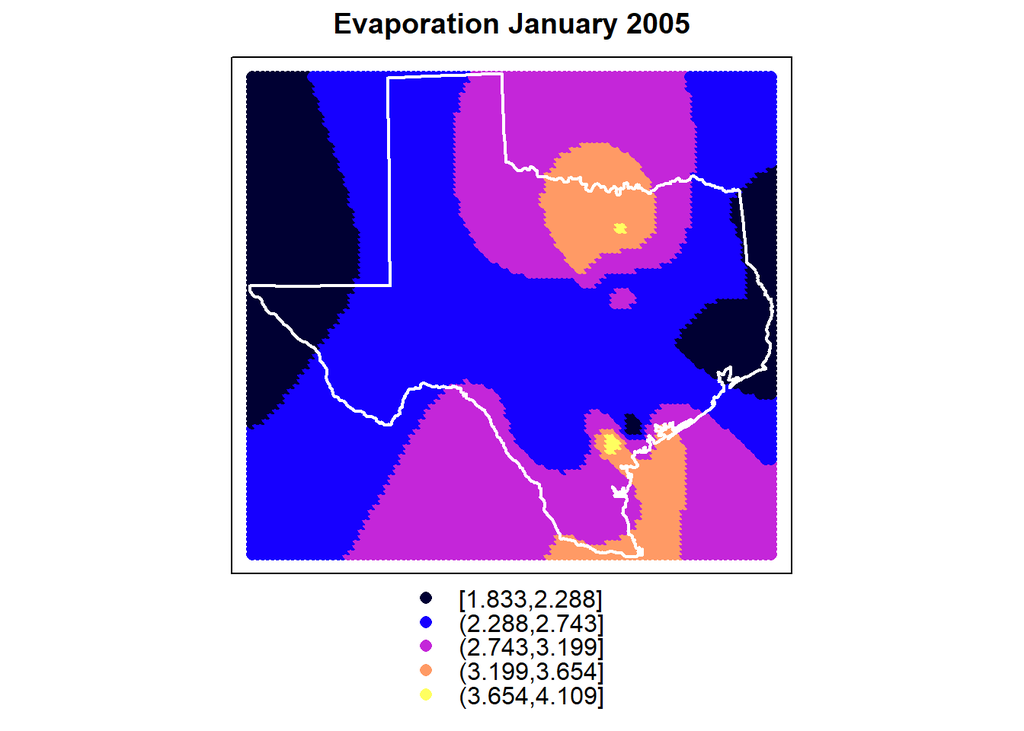

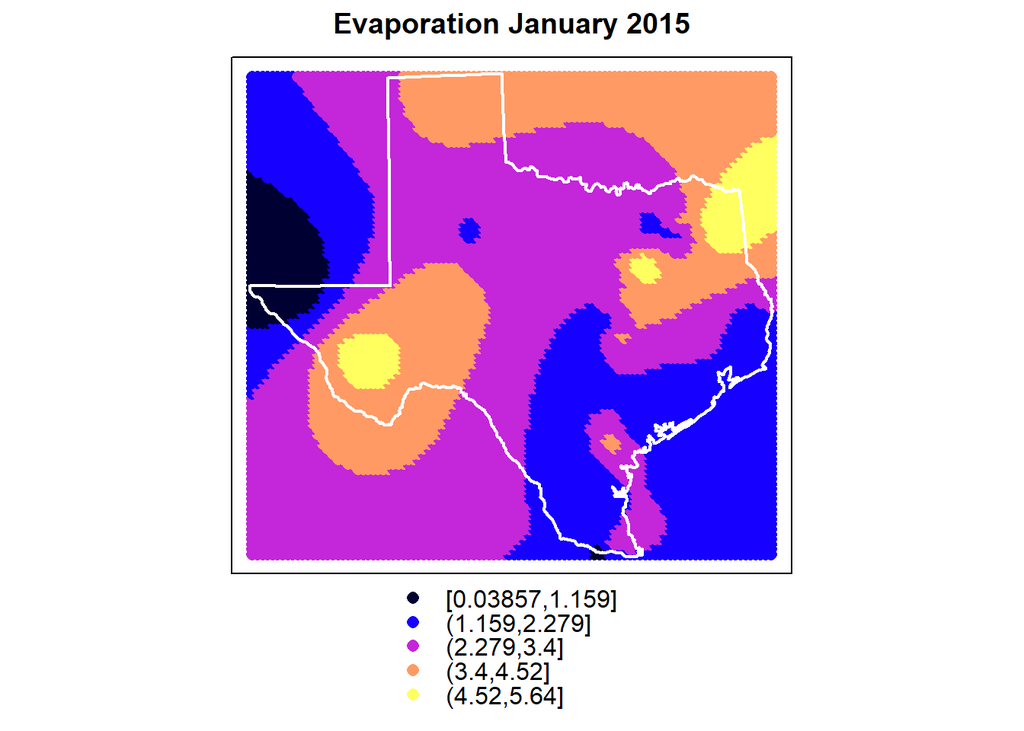

According to the previous findings the comparison of the basic statistics shows that there is no clear trend for the evaporation, but it rather seems to decrease than to increase. Another interesting thing is that the maximum evaporation and the standard deviation are highest in 2015 indicating that on sunny days the evaporation is stronger nowadays and the variations become higher.

Statistics of averaged Evaporation values in January

|  | Mean | Min | Max | Std. Dev. |
| --- | --- | --- | --- | --- |
| 1955 | 2.5339458 | 1.1032 | 4.1387 | 0.6455607 |
| 1965 | 3.2269444 | 2.3333 | 4.6591 | 0.6750646 |
| 1975 | 3.0280476 | 2.3250 | 3.9000 | 0.5105259 |
| 1985 | 2.3963696 | 1.6500 | 3.0050 | 0.3538575 |
| 1995 | 2.6494909 | 1.8577 | 3.5625 | 0.4744573 |
| 2005 | 2.7764516 | 1.8290 | 4.3812 | 0.6028067 |
| 2015 | 2.7819317 | 0.0000 | 5.8760 | 1.2305612 |
| Difference 2015 - 1955 | 0.2479859 | -1.1032 | 1.7373 | 0.5850006 |

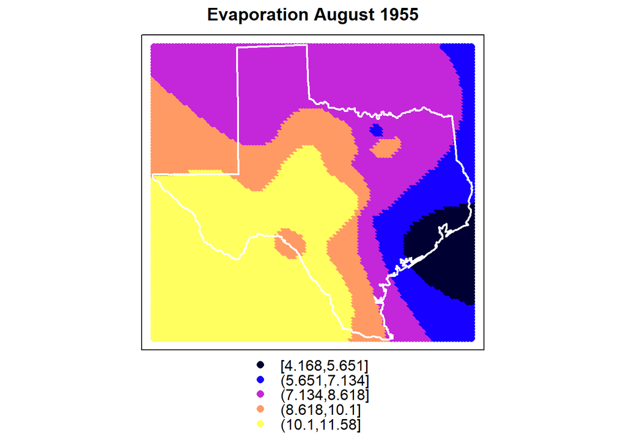

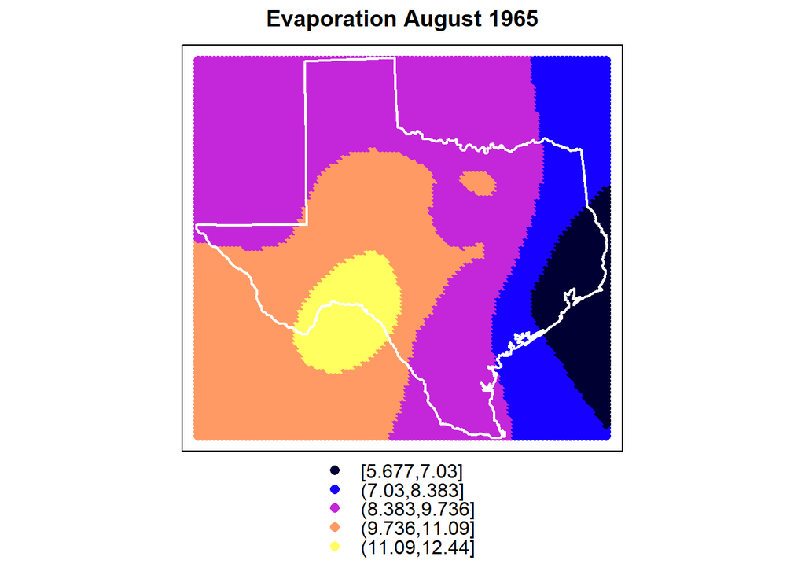

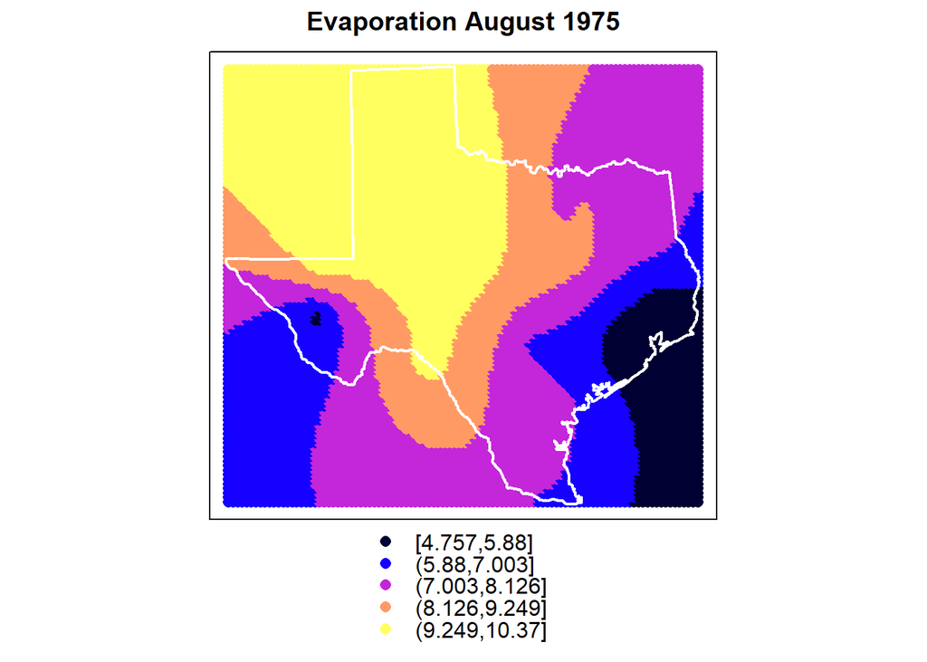

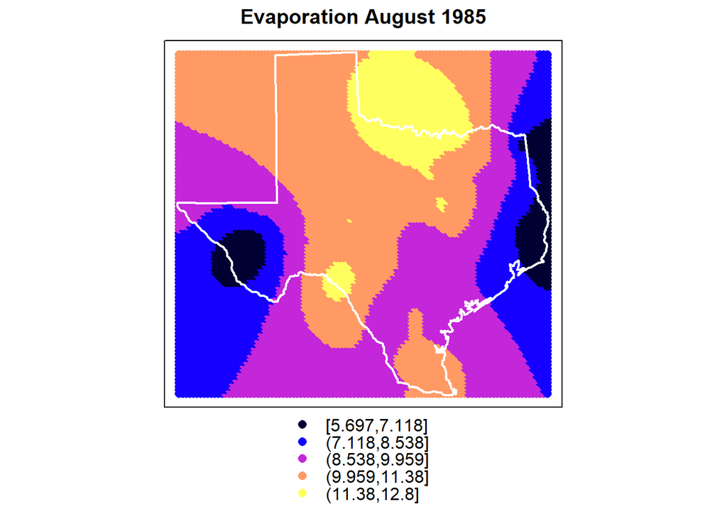

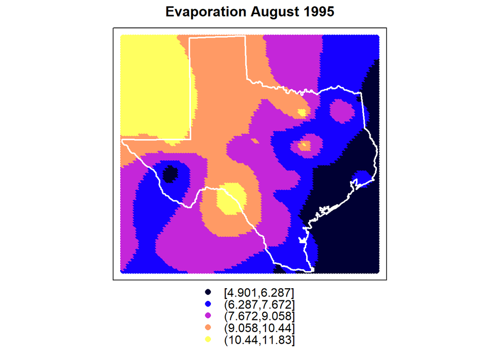

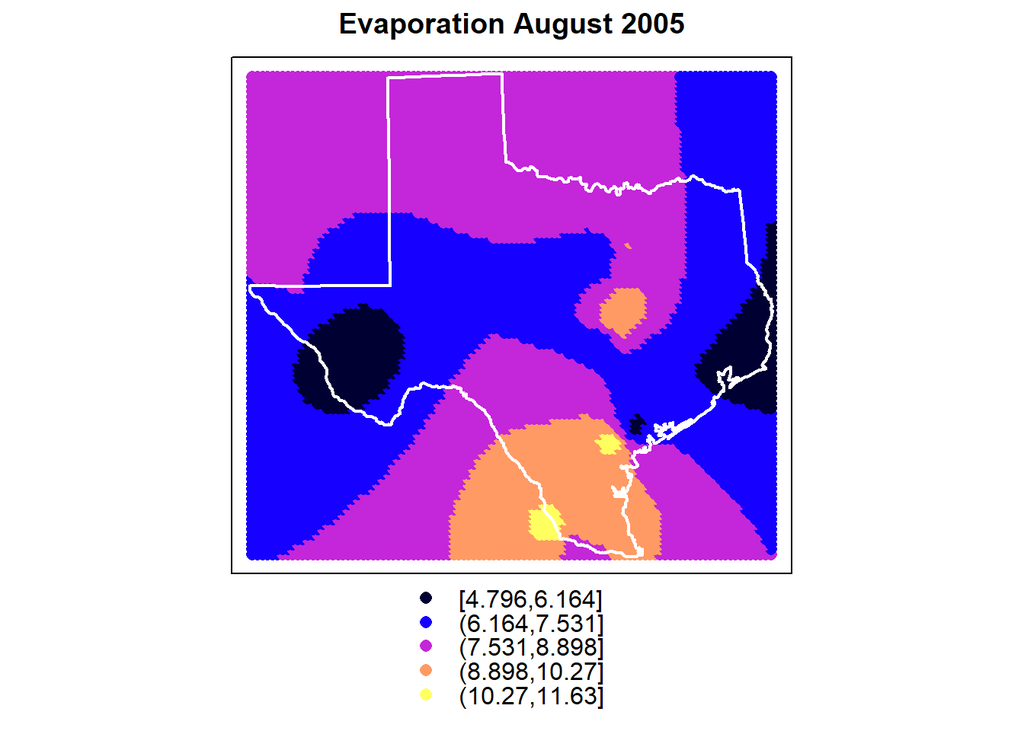

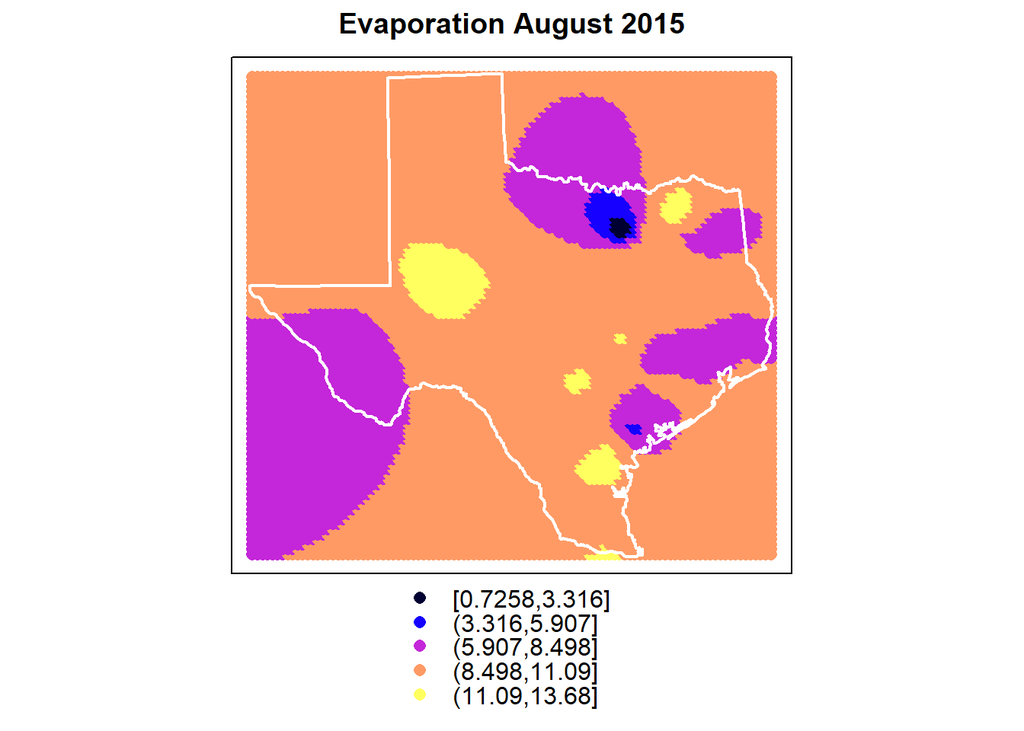

The basic statistical values in August are similar to the ones from January. Beside the values in 2015 it looks more like a decrease than an increase. Again, the maximum evaporation value and highest standard deviation is from 2015. This indicates a stronger but more rare evaporation.

Statistics of averaged Evaporation values in August

|  | Mean | Min | Max | Std. Dev. |
| --- | --- | --- | --- | --- |
| 1955 | 8.6395917 | 4.1613 | 11.7077 | 2.0953366 |
| 1965 | 9.1236619 | 5.7387 | 12.4793 | 1.4059643 |
| 1975 | 7.8349654 | 4.7387 | 10.1095 | 1.5382414 |
| 1985 | 9.6928833 | 5.5852 | 12.8217 | 1.7034808 |
| 1995 | 7.6485324 | 4.8903 | 11.9419 | 1.7720357 |
| 2005 | 8.0204029 | 4.7167 | 12.2421 | 1.6309597 |
| 2015 | 9.4469707 | 0.0000 | 13.8714 | 2.3302825 |
| Difference 2015 - 1955 | 0.8073791 | -4.1613 | 2.1637 | 0.2349459 |

If we look at both kriging results it seems like the evaporation is not changing very strongly with the climate change. According to the findings of Roderick and Farquhar there is a weak decreasing trend.

#### Comparison coast interior

The comparison of the slope of trends also shows this decrease in evaporation but must be considered carefully since the time series not cover the same temporal extent. The comparison indicates that the decrease in the interior is higher than at the coast. This stands in contrast to the higher increase of temperature in the interior.

Slope of trend of the Evaporation time series on the coast and in the interior

|  | Slope of trend |
| --- | --- |
| Angleton, East (Coast) | -0.0666252 |
| Mccook, South (Coast) | -0.0132225 |
| Benbrook, North (Interior) | 0.0048910 |
| Fort Stockton, West (Interior) | -0.1953556 |
| Mean (Coast) | -0.0399238 |
| Mean(Interior) | -0.0952323 |

### Wind

#### Time series data

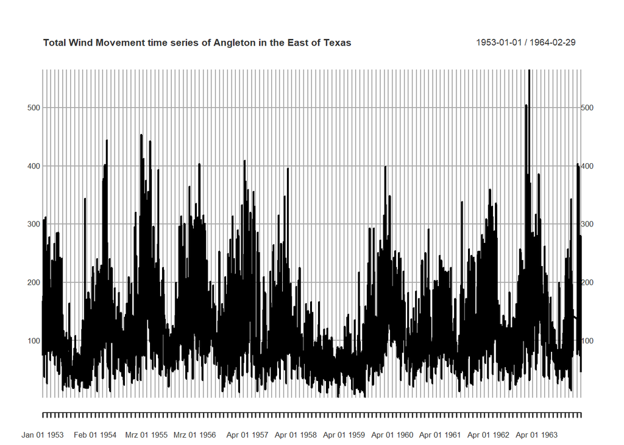

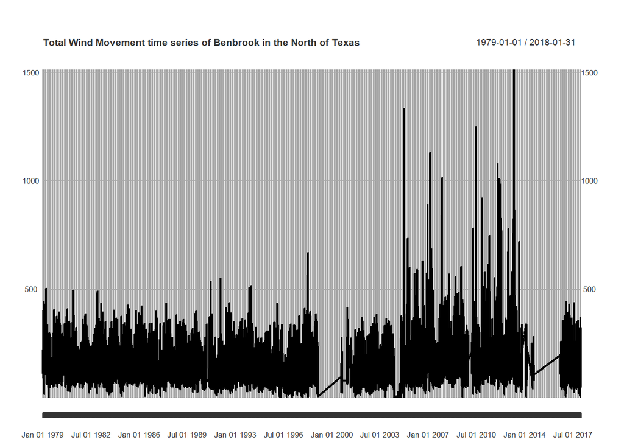

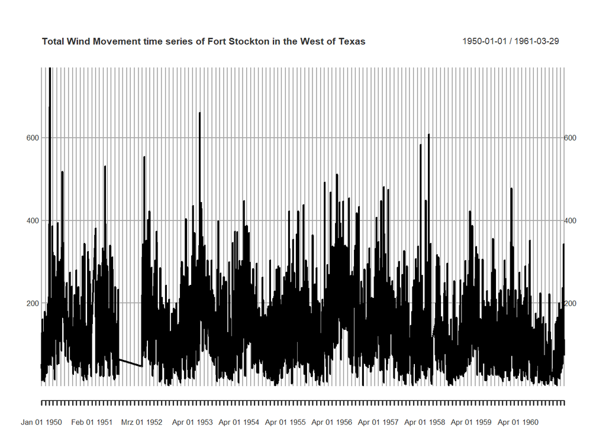

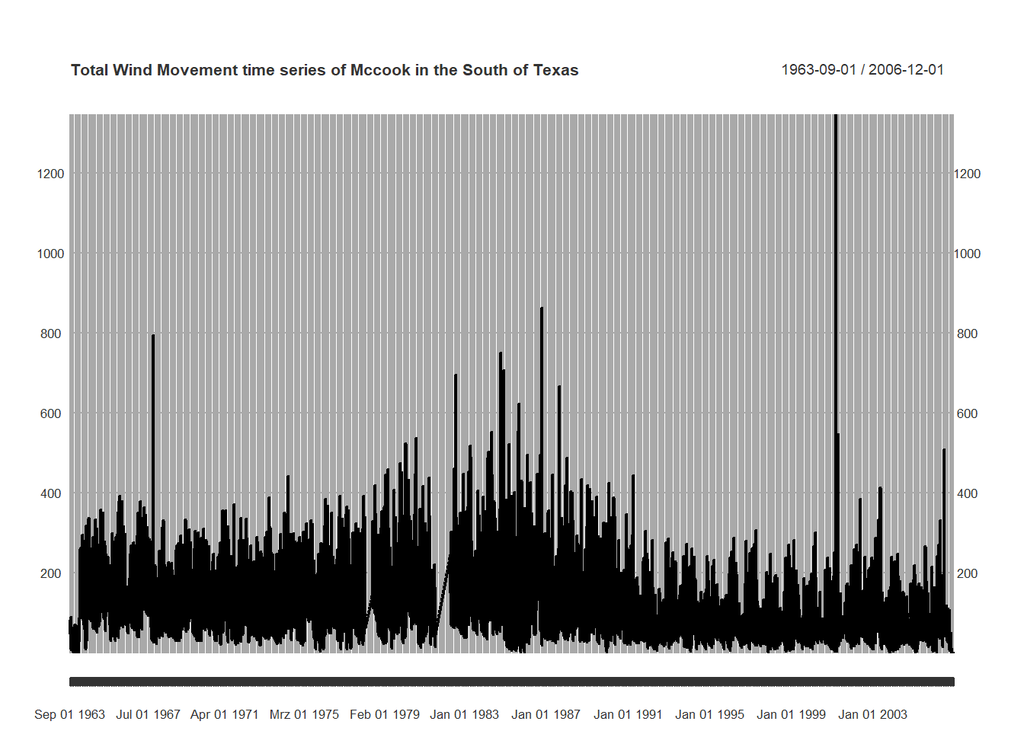

If we compare only the trends of the time series, we see a very ambiguous pattern. The time series of Angleton and Benbrook have a weak increasing trend and the time series of Fort Stockton and Mccook have a strong decreasing trend. If we only consider the time series with the longer observation periods we have one with an increasing trend (Benbrook) and one with a decreasing trend (Mccook).

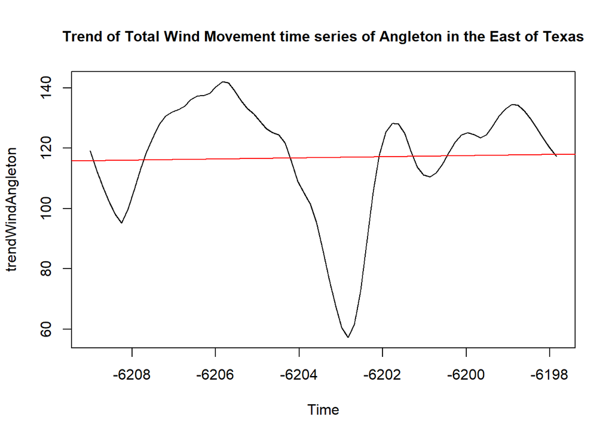

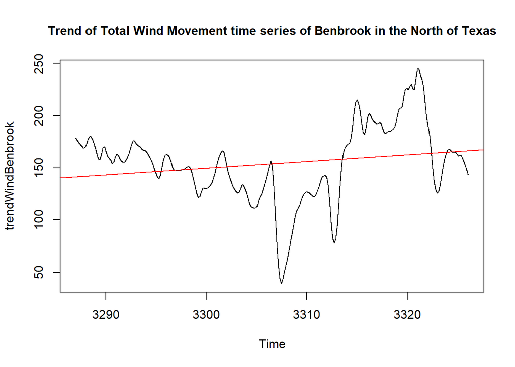

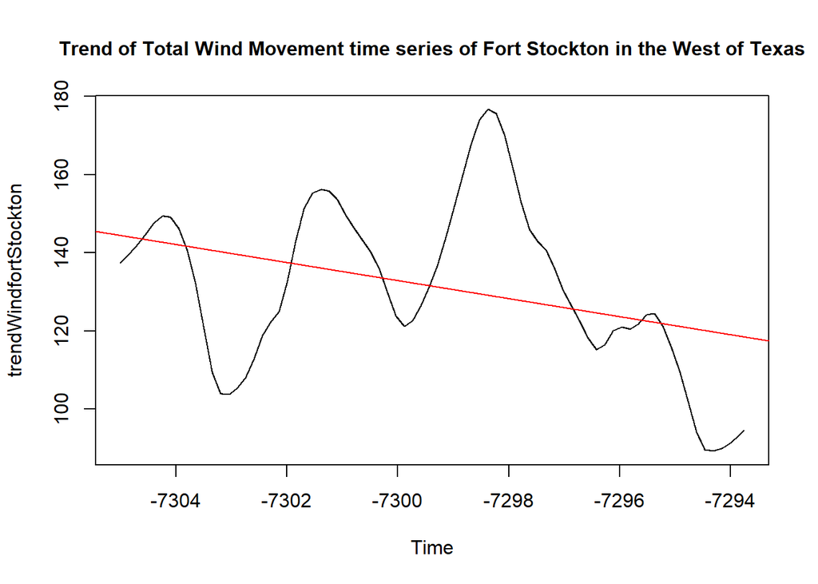

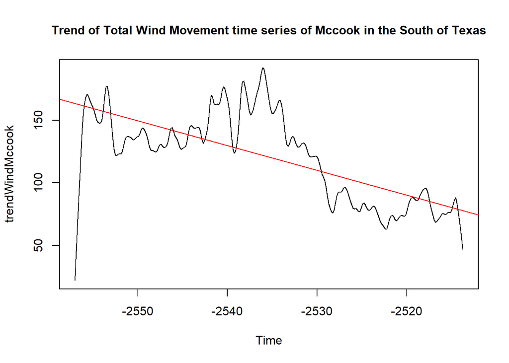

The autocorrelation plot shows the same yearly periodicity as the temperature and the evaporation time series since the wind is stronger in the winter.

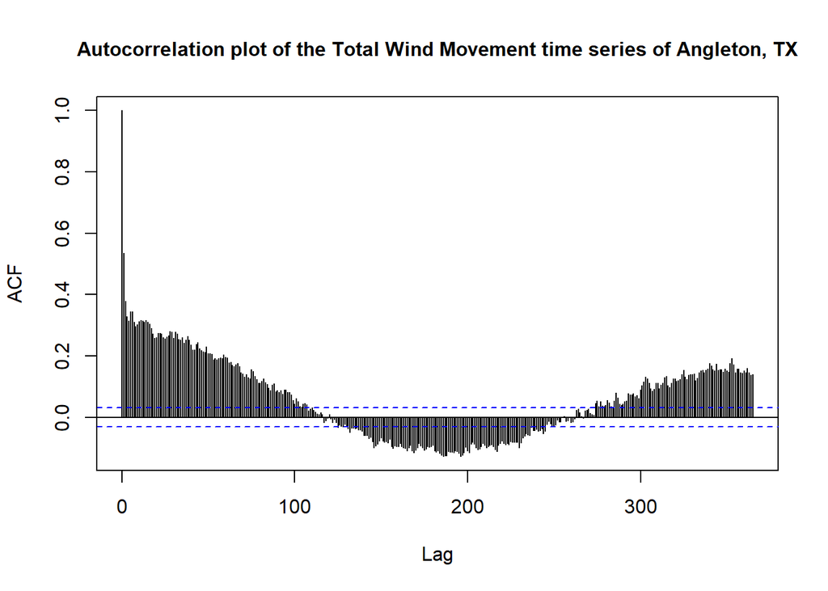

According to the trends of the time series the forecast for Angleton and Mccook are also increasing respectively decreasing. Interestingly, the forecasts for the other two stations are different than their trends. For Benbrook the forecast predicts a strong decrease in opposite to the increasing trend. An explanation for this could be that the last measurement is very high (over 200) and a decrease is most likely to occur. For Fort Stockton an increase is predicted although the trend is strongly decreasing.

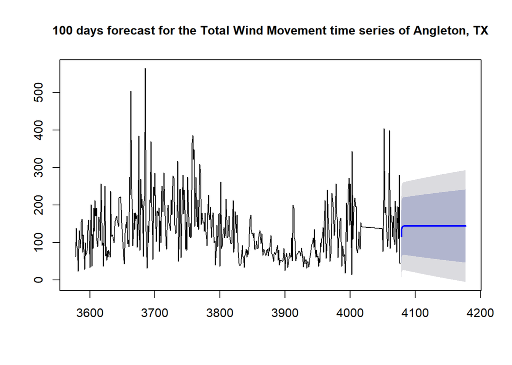